# Term Deposit Subscription Prediction_Project_3_solution

Goal:

Using the data collected from existing customers, build a model that will help the marketing team identify potential customers who are relatively more likely to subscribe term deposit and thus increase their hit ratio.

Input variables: Bank client data:

1. age: Continuous feature
2. job: Type of job (management, technician, entrepreneur, blue-collar, etc.)
3. marital: marital status (married, single, divorced)
4. education: education level (primary, secondary, tertiary)
5. default: has credit in default?
6. housing: has housing loan?
7. loan: has personal loan?
8. balance in account Related to previous contact:
9. contact: contact communication type
10. month: last contact month of year
11. day: last contact day of the month
12. duration: last contact duration, in seconds* Other attributes:
13. campaign: number of contacts performed during this campaign and for this client
14. pdays: number of days that passed by after the client was last contacted from a previous campaign (-1 tells us the person has not been contacted or contact period is beyond 900 days)
15. previous: number of times the client has been contacted before for the last campaign to subscribe term deposit
16. poutcome: outcome of the previous marketing campaign Output variable (desired target):
17. Target: Tell us has the client subscribed a term deposit. (Yes, No)

Import Libraries:

```python
import pandas as pd
import numpy as np

import matplotlib.pyplot as plt
%matplotlib inline
import seaborn as sns

from sklearn.model_selection import train_test_split
from sklearn.tree import DecisionTreeClassifier

from sklearn import metrics

from IPython.display import Image

from sklearn import tree
from os import system

import warnings
warnings.filterwarnings('ignore')
```

Read the data:

```python
bank_full=pd.read_csv("bank-full.csv")
bank_full.head(10) #we can see some unknown values in some of the columns.
```

|  | age | job | marital | education | default | balance | housing | loan | contact | day | month | duration | campaign | pdays | previous | poutcome | Target |
| --- | --- | --- | --- | --- | --- | --- | --- | --- | --- | --- | --- | --- | --- | --- | --- | --- | --- |
| 0 | 58 | management | married | tertiary | no | 2143 | yes | no | unknown | 5 | may | 261 | 1 | -1 | 0 | unknown | no |
| 1 | 44 | technician | single | secondary | no | 29 | yes | no | unknown | 5 | may | 151 | 1 | -1 | 0 | unknown | no |
| 2 | 33 | entrepreneur | married | secondary | no | 2 | yes | yes | unknown | 5 | may | 76 | 1 | -1 | 0 | unknown | no |
| 3 | 47 | blue-collar | married | unknown | no | 1506 | yes | no | unknown | 5 | may | 92 | 1 | -1 | 0 | unknown | no |
| 4 | 33 | unknown | single | unknown | no | 1 | no | no | unknown | 5 | may | 198 | 1 | -1 | 0 | unknown | no |
| 5 | 35 | management | married | tertiary | no | 231 | yes | no | unknown | 5 | may | 139 | 1 | -1 | 0 | unknown | no |
| 6 | 28 | management | single | tertiary | no | 447 | yes | yes | unknown | 5 | may | 217 | 1 | -1 | 0 | unknown | no |
| 7 | 42 | entrepreneur | divorced | tertiary | yes | 2 | yes | no | unknown | 5 | may | 380 | 1 | -1 | 0 | unknown | no |
| 8 | 58 | retired | married | primary | no | 121 | yes | no | unknown | 5 | may | 50 | 1 | -1 | 0 | unknown | no |
| 9 | 43 | technician | single | secondary | no | 593 | yes | no | unknown | 5 | may | 55 | 1 | -1 | 0 | unknown | no |

Univariate and Multivariate Analysis:

```python
bank_full.shape
```

```
(45211, 17)
```

```python
bank_full.describe()
```

|  | age | balance | day | duration | campaign | pdays | previous |
| --- | --- | --- | --- | --- | --- | --- | --- |
| count | 45211.000000 | 45211.000000 | 45211.000000 | 45211.000000 | 45211.000000 | 45211.000000 | 45211.000000 |
| mean | 40.936210 | 1362.272058 | 15.806419 | 258.163080 | 2.763841 | 40.197828 | 0.580323 |
| std | 10.618762 | 3044.765829 | 8.322476 | 257.527812 | 3.098021 | 100.128746 | 2.303441 |
| min | 18.000000 | -8019.000000 | 1.000000 | 0.000000 | 1.000000 | -1.000000 | 0.000000 |
| 25% | 33.000000 | 72.000000 | 8.000000 | 103.000000 | 1.000000 | -1.000000 | 0.000000 |
| 50% | 39.000000 | 448.000000 | 16.000000 | 180.000000 | 2.000000 | -1.000000 | 0.000000 |
| 75% | 48.000000 | 1428.000000 | 21.000000 | 319.000000 | 3.000000 | -1.000000 | 0.000000 |
| max | 95.000000 | 102127.000000 | 31.000000 | 4918.000000 | 63.000000 | 871.000000 | 275.000000 |

There are some extreme outliers in balance, duration,campaign,pdays and previous.

```python
bank_full.info()
```

```
<class 'pandas.core.frame.DataFrame'>
RangeIndex: 45211 entries, 0 to 45210
Data columns (total 17 columns):
 #   Column     Non-Null Count  Dtype
---  ------     --------------  -----
 0   age        45211 non-null  int64
 1   job        45211 non-null  object
 2   marital    45211 non-null  object
 3   education  45211 non-null  object
 4   default    45211 non-null  object
 5   balance    45211 non-null  int64
 6   housing    45211 non-null  object
 7   loan       45211 non-null  object
 8   contact    45211 non-null  object
 9   day        45211 non-null  int64
 10  month      45211 non-null  object
 11  duration   45211 non-null  int64
 12  campaign   45211 non-null  int64
 13  pdays      45211 non-null  int64
 14  previous   45211 non-null  int64
 15  poutcome   45211 non-null  object
 16  Target     45211 non-null  object
dtypes: int64(7), object(10)
memory usage: 5.9+ MB
```

```python
bank_full.isnull().sum()
```

```
age          0
job          0
marital      0
education    0
default      0
balance      0
housing      0
loan         0
contact      0
day          0
month        0
duration     0
campaign     0
pdays        0
previous     0
poutcome     0
Target       0
dtype: int64
```

Insights: There is no null values.

```python
bank_full.nunique()
```

```
age            77
job            12
marital         3
education       4
default         2
balance      7168
housing         2
loan            2
contact         3
day            31
month          12
duration     1573
campaign       48
pdays         559
previous       41
poutcome        4
Target          2
dtype: int64
```

Job,Marital,education,default,housing,loan,contact,month,poutcome and target variable, all these are object Dtype.

```python
bank_full.corr()
```

|  | age | balance | day | duration | campaign | pdays | previous |
| --- | --- | --- | --- | --- | --- | --- | --- |
| age | 1.000000 | 0.097783 | -0.009120 | -0.004648 | 0.004760 | -0.023758 | 0.001288 |
| balance | 0.097783 | 1.000000 | 0.004503 | 0.021560 | -0.014578 | 0.003435 | 0.016674 |
| day | -0.009120 | 0.004503 | 1.000000 | -0.030206 | 0.162490 | -0.093044 | -0.051710 |
| duration | -0.004648 | 0.021560 | -0.030206 | 1.000000 | -0.084570 | -0.001565 | 0.001203 |
| campaign | 0.004760 | -0.014578 | 0.162490 | -0.084570 | 1.000000 | -0.088628 | -0.032855 |
| pdays | -0.023758 | 0.003435 | -0.093044 | -0.001565 | -0.088628 | 1.000000 | 0.454820 |
| previous | 0.001288 | 0.016674 | -0.051710 | 0.001203 | -0.032855 | 0.454820 | 1.000000 |

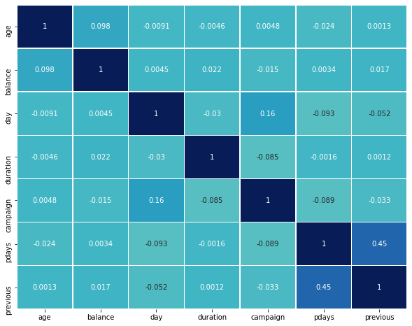

```python
plt.figure(figsize=(10,8))
sns.heatmap(bank_full.corr(),
            annot=True,
            linewidths=.5,
            center=0,
            cbar=False,
            cmap="YlGnBu")
plt.show()
```

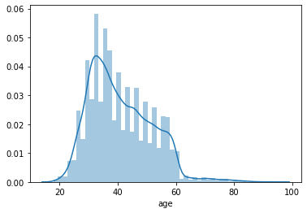

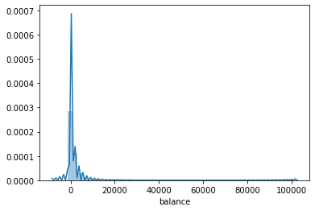

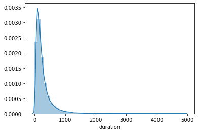

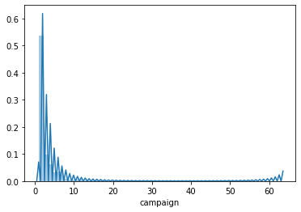

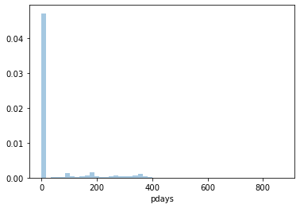

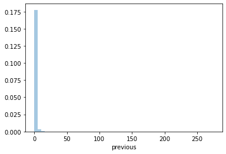

```python
# distplot for continous columns
for i in ['age', 'balance', 'duration', 'campaign','pdays','previous']:
    sns.distplot(bank_full[i],kde=True )
    plt.show()
```

As you can see all these are skewed.

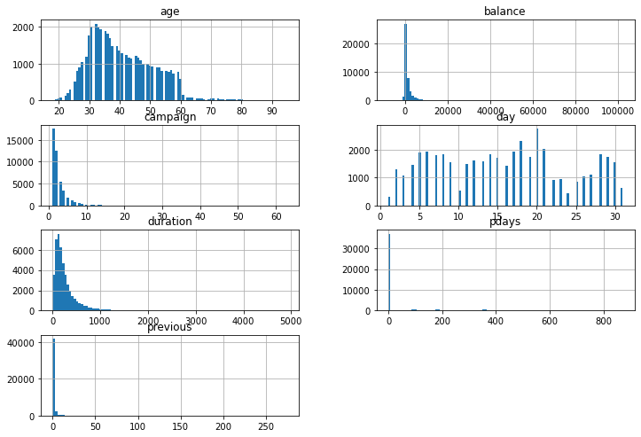

```python
bank_full.hist(stacked=False, bins=100, figsize=(12,30), layout=(14,2)); # balance,campaign, duration,pdays,previous all these are highly skewed.
```

Insights: Data is rightly skewed.

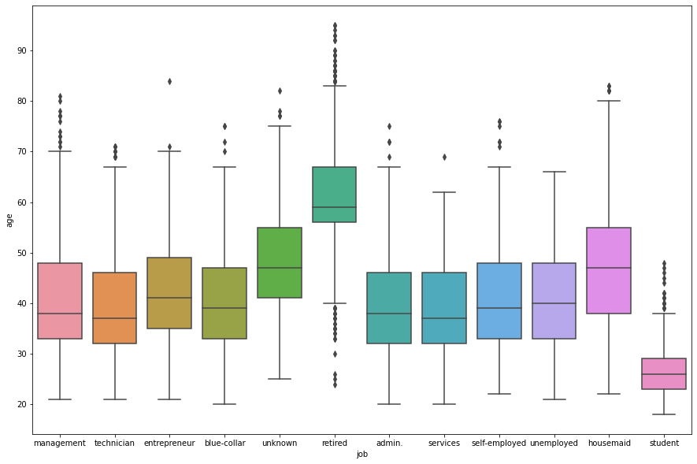

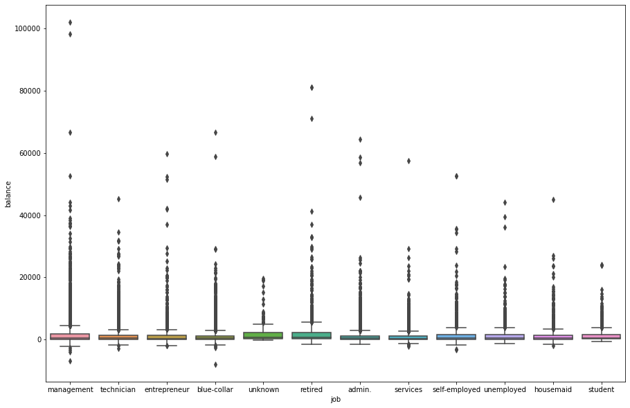

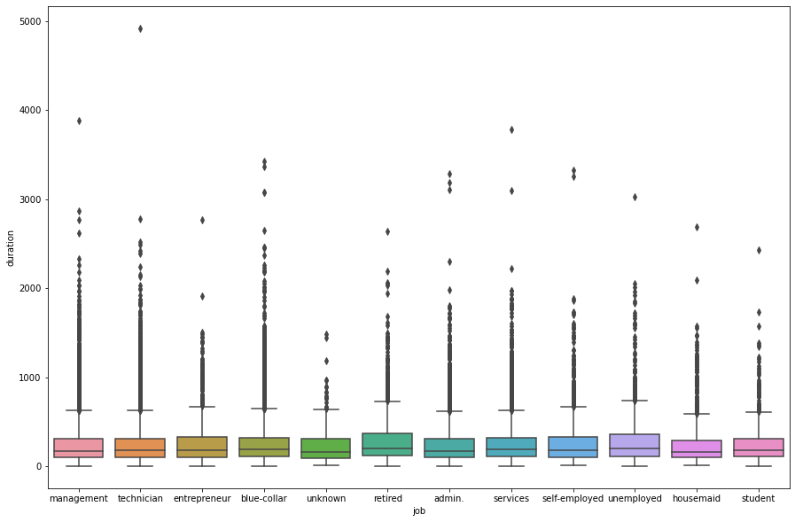

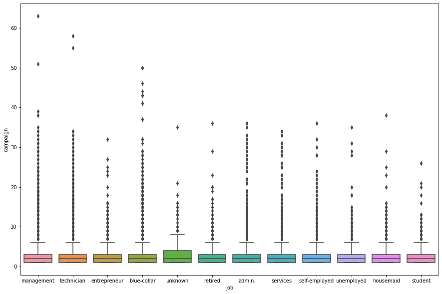

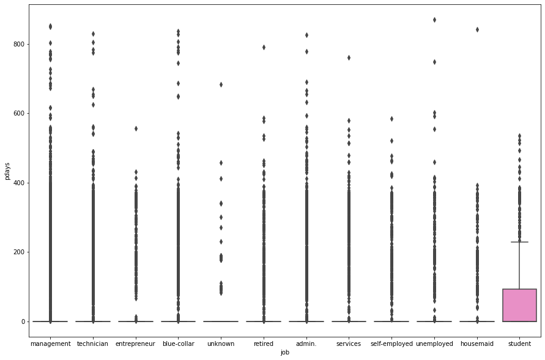

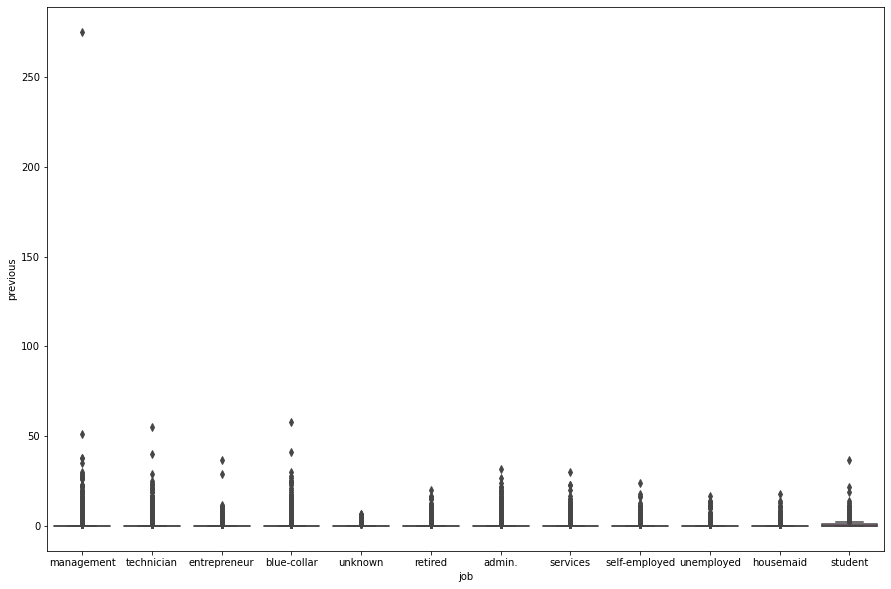

```python
 # makes the plot wider
for i in ['age', 'balance', 'duration', 'campaign','pdays','previous']:
    plt.figure(figsize=(15,10))
    sns.boxplot(bank_full['job'], bank_full[i])
    plt.show()
```

There are no. of extreme outliers.

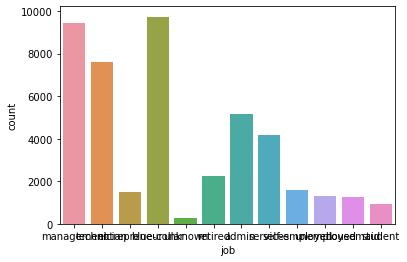

```
Value counts:
 blue-collar      0.215257
management       0.209197
technician       0.168034
admin.           0.114375
services         0.091880
retired          0.050076
self-employed    0.034925
entrepreneur     0.032890
unemployed       0.028820
housemaid        0.027427
student          0.020747
unknown          0.006370
Name: job, dtype: float64
```

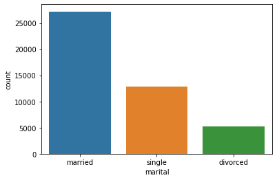

```
Value counts:
 married     0.601933
single      0.282896
divorced    0.115171
Name: marital, dtype: float64
```

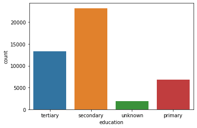

```
Value counts:
 secondary    0.513194
tertiary     0.294198
primary      0.151534
unknown      0.041074
Name: education, dtype: float64
```

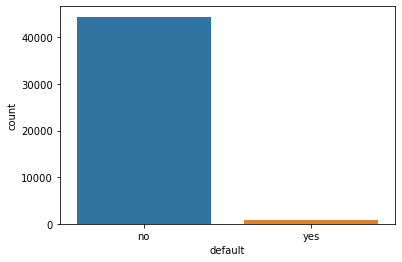

```
Value counts:
 no     0.981973
yes    0.018027
Name: default, dtype: float64
```

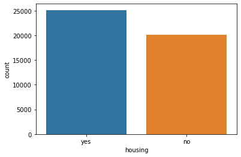

```
Value counts:
 yes    0.555838
no     0.444162
Name: housing, dtype: float64
```

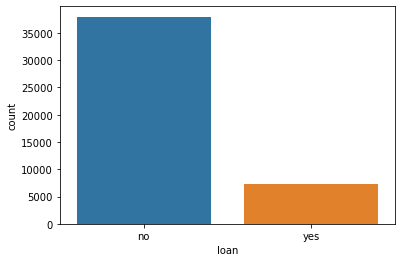

```
Value counts:
 no     0.839774
yes    0.160226
Name: loan, dtype: float64
```

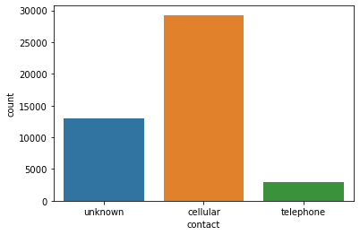

```
Value counts:
 cellular     0.647741
unknown      0.287983
telephone    0.064276
Name: contact, dtype: float64
```

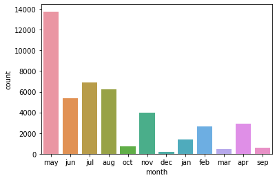

```
Value counts:
 may    0.304483
jul    0.152507
aug    0.138174
jun    0.118135
nov    0.087810
apr    0.064851
feb    0.058592
jan    0.031032
oct    0.016323
sep    0.012807
mar    0.010551
dec    0.004733
Name: month, dtype: float64
```

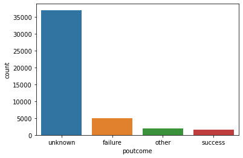

```
Value counts:
 unknown    0.817478
failure    0.108403
other      0.040698
success    0.033421
Name: poutcome, dtype: float64
```

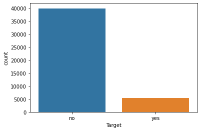

```
Value counts:
 no     0.883015
yes    0.116985
Name: Target, dtype: float64
```

```python
 for i in [ 'job','marital', 'education', 'default', 'housing','loan', 'contact', 'month', 'poutcome','Target']:
    sns.countplot(bank_full[i])
    plt.show()
    print ( 'Value counts:\n', bank_full[i].value_counts(normalize=True))
```

Insights:

1. We can clearly say that there is no null values .But job,education,contact and poutcome has some unknown values.
2. Maximum no. of clients who subscribed the term deposit are contacted in the month of may.
3. We can see that more than 81% of poutcome is unknown, which would not provide any info to the algorithms.(we will drop this column).
4. Data imbalance is there in Target Variable.

```python
bank_full.drop(['poutcome'],axis=1,inplace=True)#Dropping poutcome column
```

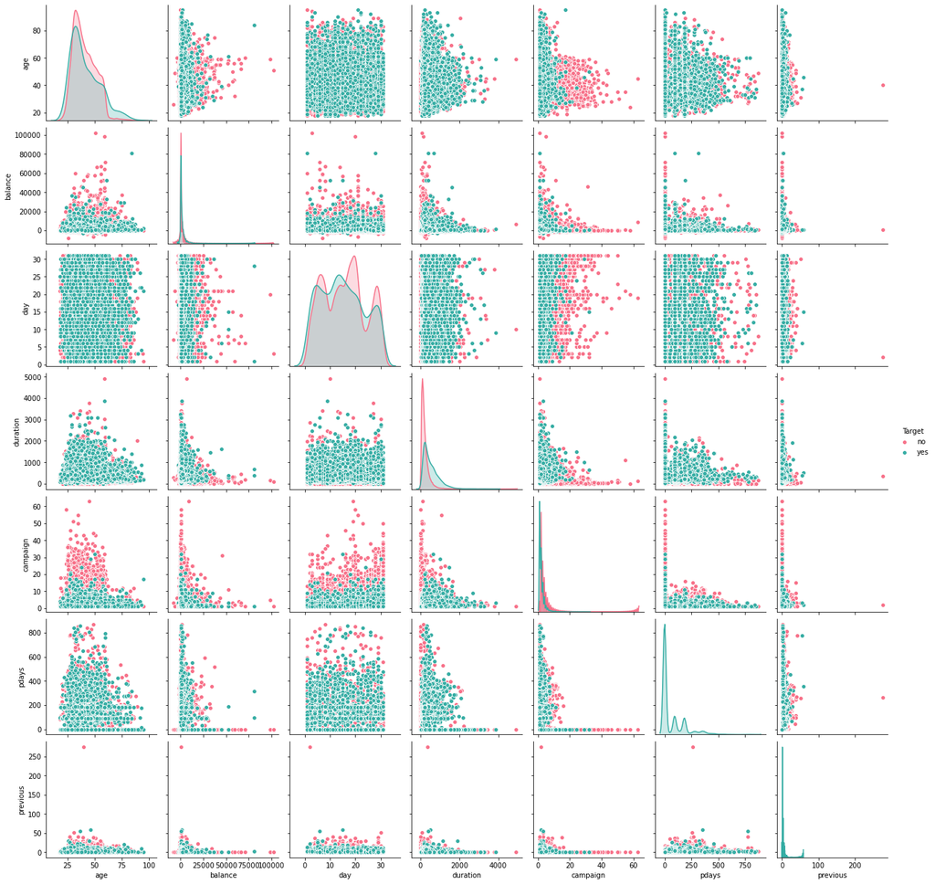

```python
sns.pairplot(bank_full,hue="Target",palette="husl");
```

```python
term_deposit=bank_full[bank_full['Target']=='yes'] #Client who has subscribed a term deposit
```

```python
(term_deposit['campaign']>= 3).value_counts(normalize=True)
```

```
False    0.749102
True     0.250898
Name: campaign, dtype: float64
```

```python
(term_deposit['pdays']==-1).value_counts(normalize=True) #-1 tells us the person has not been contacted or contact period is beyond 900 days)
```

```
True     0.639818
False    0.360182
Name: pdays, dtype: float64
```

```python
(term_deposit['previous']==0).value_counts(normalize=True) # number of times the client has been contacted before for the last campaign to subscribe term deposit
```

```
True     0.639818
False    0.360182
Name: previous, dtype: float64
```

Insights:

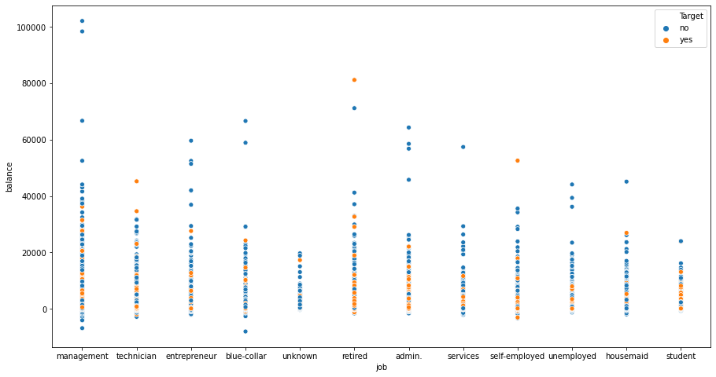

```python
plt.figure(figsize=(15,8)) # makes the plot wider
sns.scatterplot(bank_full['job'], bank_full['balance'],hue=bank_full['Target']);
```

Insights: Retired,students,self-employed,unemployed and admins with lower balance in their accounts are subscribing more term deposit.

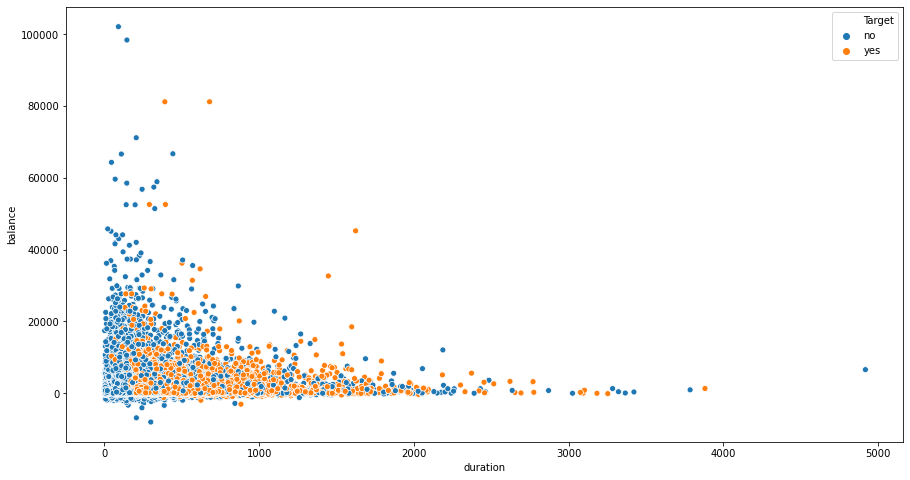

```python
plt.figure(figsize=(15,8)) # makes the plot wider
sns.scatterplot(bank_full['duration'], bank_full['balance'],hue=bank_full['Target']);
```

```python
bank_full.groupby(['Target']).mean()
```

| Target | age | balance | day | duration | campaign | pdays | previous |
| --- | --- | --- | --- | --- | --- | --- | --- |
| no | 40.838986 | 1303.714969 | 15.892290 | 221.182806 | 2.846350 | 36.421372 | 0.502154 |
| yes | 41.670070 | 1804.267915 | 15.158253 | 537.294574 | 2.141047 | 68.702968 | 1.170354 |

```python
bank_full.groupby(['Target']).median()
```

| Target | age | balance | day | duration | campaign | pdays | previous |
| --- | --- | --- | --- | --- | --- | --- | --- |
| no | 39 | 417 | 16 | 164 | 2 | -1 | 0 |
| yes | 38 | 733 | 15 | 426 | 2 | -1 | 0 |

```python
pd.crosstab(bank_full['job'],bank_full['Target'],normalize='index')# Retired and student has subscribed more a term deposit.
```

| Target job | no | yes |
| --- | --- | --- |
| admin. | 0.877973 | 0.122027 |
| blue-collar | 0.927250 | 0.072750 |
| entrepreneur | 0.917283 | 0.082717 |
| housemaid | 0.912097 | 0.087903 |
| management | 0.862444 | 0.137556 |
| retired | 0.772085 | 0.227915 |
| self-employed | 0.881571 | 0.118429 |
| services | 0.911170 | 0.088830 |
| student | 0.713220 | 0.286780 |
| technician | 0.889430 | 0.110570 |
| unemployed | 0.844973 | 0.155027 |
| unknown | 0.881944 | 0.118056 |

```python
pd.crosstab(bank_full['marital'],bank_full['Target'],normalize='index') #single people has subscribed more term deposit.
```

| Target marital | no | yes |
| --- | --- | --- |
| divorced | 0.880545 | 0.119455 |
| married | 0.898765 | 0.101235 |
| single | 0.850508 | 0.149492 |

```python
pd.crosstab(bank_full['education'],bank_full['Target'],normalize='columns') # has almost same distribution
```

| Target education | no | yes |
| --- | --- | --- |
| primary | 0.156806 | 0.111741 |
| secondary | 0.519814 | 0.463226 |
| tertiary | 0.283177 | 0.377387 |
| unknown | 0.040203 | 0.047646 |

```python
pd.crosstab(bank_full['default'],bank_full['Target'],normalize='columns') # has almost same distribution
```

| Target default | no | yes |
| --- | --- | --- |
| no | 0.980888 | 0.990168 |
| yes | 0.019112 | 0.009832 |

```python
pd.crosstab(bank_full['housing'],bank_full['Target'],normalize='columns') # client with no housing loan are more likely to subscribe a term deposit
```

| Target housing | no | yes |
| --- | --- | --- |
| no | 0.418992 | 0.634146 |
| yes | 0.581008 | 0.365854 |

```python
pd.crosstab(bank_full['loan'],bank_full['Target'],normalize='columns')# We should check how this feature influences final model using coefficients.
```

| Target loan | no | yes |
| --- | --- | --- |
| no | 0.83067 | 0.908489 |
| yes | 0.16933 | 0.091511 |

```python
pd.crosstab(bank_full['contact'],bank_full['Target'],normalize='columns') # Clients with cellular contact are more likely to subscribe term deposit
```

| Target contact | no | yes |
| --- | --- | --- |
| cellular | 0.624117 | 0.826054 |
| telephone | 0.063023 | 0.073738 |
| unknown | 0.312860 | 0.100208 |

```python
pd.crosstab(bank_full['month'],bank_full['Target'],normalize='columns') # clients who are contacted in the month of may has subscribed more deposit term.
```

| Target month | no | yes |
| --- | --- | --- |
| apr | 0.058990 | 0.109094 |
| aug | 0.139247 | 0.130081 |
| dec | 0.002856 | 0.018907 |
| feb | 0.055308 | 0.083381 |
| jan | 0.031587 | 0.026848 |
| jul | 0.157006 | 0.118548 |
| jun | 0.120109 | 0.103233 |
| mar | 0.005736 | 0.046890 |
| may | 0.321652 | 0.174891 |
| nov | 0.089349 | 0.076196 |
| oct | 0.010395 | 0.061070 |
| sep | 0.007765 | 0.050860 |

Prepare the data for analysis:

```python
from sklearn.preprocessing import LabelEncoder   # import label encoder

labelencoder = LabelEncoder()
for i in ['job', 'marital', 'education', 'default',  'housing','loan', 'contact',  'month']:
     bank_full[i] = labelencoder.fit_transform(bank_full[i])
bank_full.head()
```

|  | age | job | marital | education | default | balance | housing | loan | contact | day | month | duration | campaign | pdays | previous | Target |
| --- | --- | --- | --- | --- | --- | --- | --- | --- | --- | --- | --- | --- | --- | --- | --- | --- |
| 0 | 58 | 4 | 1 | 2 | 0 | 2143 | 1 | 0 | 2 | 5 | 8 | 261 | 1 | -1 | 0 | no |
| 1 | 44 | 9 | 2 | 1 | 0 | 29 | 1 | 0 | 2 | 5 | 8 | 151 | 1 | -1 | 0 | no |
| 2 | 33 | 2 | 1 | 1 | 0 | 2 | 1 | 1 | 2 | 5 | 8 | 76 | 1 | -1 | 0 | no |
| 3 | 47 | 1 | 1 | 3 | 0 | 1506 | 1 | 0 | 2 | 5 | 8 | 92 | 1 | -1 | 0 | no |
| 4 | 33 | 11 | 2 | 3 | 0 | 1 | 0 | 0 | 2 | 5 | 8 | 198 | 1 | -1 | 0 | no |

```python
# making copies of dataframe for logistic model and ensemble model.
bank_full_lr=bank_full.copy()
bank_full_dt=bank_full.copy()
```

Normalization:(handling outliers)

```python
#shifting the data by adding all the numbers with the absolute of most negative number(minimum value of the data) for balance and pdays

bank_full_lr['balance']=bank_full_lr['balance']+ (8019.000000)
bank_full_lr['pdays']=bank_full_lr['pdays']+ (1.000000)
```

```python
# applying log transform
from sklearn.preprocessing import FunctionTransformer
log_transformer = FunctionTransformer(np.log1p)
```

```python
bank_full_lr['balance_logtransform'] = log_transformer.fit_transform(bank_full_lr[['balance']])
bank_full_lr['duration_logtransform'] = log_transformer.fit_transform(bank_full_lr[['duration']])
bank_full_lr['campaign_logtransform'] = log_transformer.fit_transform(bank_full_lr[['campaign']])
bank_full_lr['pdays_logtransform'] = log_transformer.fit_transform(bank_full_lr[['pdays']])
bank_full_lr['previous_logtransform'] = log_transformer.fit_transform(bank_full_lr[['previous']])
```

```python
#Convert X & Y variable to a categorical variable wherever relevant
for i in ['job', 'marital', 'education','default',  'housing','loan','month', 'contact','Target']:
    bank_full_lr[i] = bank_full_lr[i].astype('category')
bank_full_lr.dtypes
```

```
age                         int64
job                      category
marital                  category
education                category
default                  category
balance                   float64
housing                  category
loan                     category
contact                  category
day                         int64
month                    category
duration                    int64
campaign                    int64
pdays                     float64
previous                    int64
Target                   category
balance_logtransform      float64
duration_logtransform     float64
campaign_logtransform     float64
pdays_logtransform        float64
previous_logtransform     float64
dtype: object
```

split training set and test set in ratio of 70:30 :

```python
## Define X and Y variables

X = bank_full_lr.drop('Target', axis=1)
X = pd.get_dummies(X, drop_first=True)
Y = bank_full_lr['Target']
Y = pd.get_dummies(Y, drop_first=True)
```

```python
##Split into training and test set
X_train, X_test, Y_train, Y_test = train_test_split(X, Y, test_size=0.30,random_state=10)
```

```
0.8882990488829905
0.8915511648481274
```

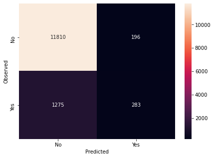

```
Recall: 0.1816431322207959

Precision: 0.5908141962421712

F1 Score: 0.2778595974472263

Roc Auc Score: 0.5826589807364182
```

```python
from sklearn.linear_model import LogisticRegression
from sklearn.metrics import confusion_matrix, recall_score, precision_score, f1_score, roc_auc_score,accuracy_score

logreg = LogisticRegression(random_state=10)
logreg.fit(X_train, Y_train)                    # fit the model on train data

Y_predict = logreg.predict(X_test)

print(logreg.score(X_train, Y_train))
print(logreg.score(X_test, Y_test))

cm=metrics.confusion_matrix(Y_test, Y_predict, labels=[0, 1])

df_cm = pd.DataFrame(cm, index = [i for i in ["No","Yes"]],
                  columns = [i for i in ["No","Yes"]])
plt.figure(figsize = (7,5))
sns.heatmap(df_cm, annot=True ,fmt='g')
plt.ylabel('Observed')
plt.xlabel('Predicted')
plt.show()

print("Recall:",recall_score(Y_test,Y_predict))
print()
print("Precision:",precision_score(Y_test,Y_predict))
print()
print("F1 Score:",f1_score(Y_test,Y_predict))
print()
print("Roc Auc Score:",roc_auc_score(Y_test,Y_predict))
```

```python
# create a dataframe to insert all values:
cmd = pd.DataFrame(columns=["Model","training_accuracy","testing_accuracy","Recall", "Precision","F1 Score","RocAucScore"])
```

```python
cmd=cmd.append({'Model':'Logreg','training_accuracy':logreg.score(X_train, Y_train) ,'testing_accuracy':logreg.score(X_test, Y_test),'Recall': recall_score(Y_test,Y_predict), 'Precision': precision_score(Y_test,Y_predict),
            'F1 Score': f1_score(Y_test,Y_predict),'RocAucScore':roc_auc_score(Y_test,Y_predict)}, ignore_index=True)
```

```python
X = bank_full_dt.drop('Target', axis=1)
Y = bank_full_dt['Target']
Y = pd.get_dummies(Y, drop_first=True)
```

```python
##Split into training and test set
X_train, X_test, Y_train, Y_test = train_test_split(X, Y, test_size=0.30,random_state=10)
```

```python
dTree = DecisionTreeClassifier(criterion = 'entropy', random_state=10)
dTree.fit(X_train, Y_train)
print(dTree.score(X_train, Y_train))
print(dTree.score(X_test, Y_test))
```

```
1.0
0.8771748746682395
```

Reducing overfitting (Regularization):

```
0.8978418175498467
0.897670303745208
```

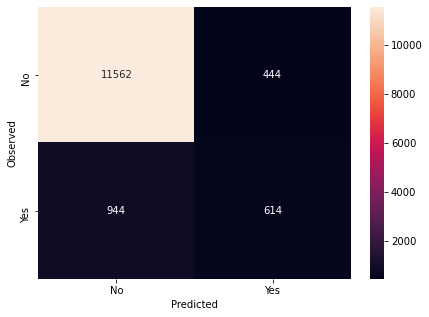

```
Recall: 0.3940949935815148

Precision: 0.5803402646502835

F1 Score: 0.46941896024464835

Roc Auc Score: 0.6785567421680687
```

```python
dTreeR = DecisionTreeClassifier(criterion = 'entropy', max_depth = 6, random_state=10)
dTreeR.fit(X_train, Y_train)
Y_predict = dTreeR.predict(X_test)

print(dTreeR.score(X_train, Y_train))
print(dTreeR.score(X_test, Y_test))

cm=metrics.confusion_matrix(Y_test, Y_predict, labels=[0, 1])

df_cm = pd.DataFrame(cm, index = [i for i in ["No","Yes"]],
                  columns = [i for i in ["No","Yes"]])
plt.figure(figsize = (7,5))
sns.heatmap(df_cm, annot=True ,fmt='g')
plt.ylabel('Observed')
plt.xlabel('Predicted')
plt.show()

print("Recall:",recall_score(Y_test,Y_predict))
print()
print("Precision:",precision_score(Y_test,Y_predict))
print()
print("F1 Score:",f1_score(Y_test,Y_predict))
print()
print("Roc Auc Score:",roc_auc_score(Y_test,Y_predict))
```

```python
cmd=cmd.append({'Model':'DTree','training_accuracy':dTreeR.score(X_train, Y_train) ,'testing_accuracy':dTreeR.score(X_test, Y_test),'Recall': recall_score(Y_test,Y_predict), 'Precision': precision_score(Y_test,Y_predict),
            'F1 Score': f1_score(Y_test,Y_predict), 'RocAucScore':roc_auc_score(Y_test,Y_predict)}, ignore_index=True)
```